# edaa

2023-12-14

Four characteristics make up the Iris dataset: sepal length, sepal width, petal length, and petal width. These characteristics allow one to identify trends and differences amongst iris species. My goal is to use exploratory data analysis (EDA) to uncover these inherent distinctions and demonstrate the value of exploratory analysis in comprehending plant variety.

```r
# Load the Iris dataset
data(iris)

# View the first few rows of the dataset
head(iris)
```

```
##   Sepal.Length Sepal.Width Petal.Length Petal.Width Species
## 1          5.1         3.5          1.4         0.2  setosa
## 2          4.9         3.0          1.4         0.2  setosa
## 3          4.7         3.2          1.3         0.2  setosa
## 4          4.6         3.1          1.5         0.2  setosa
## 5          5.0         3.6          1.4         0.2  setosa
## 6          5.4         3.9          1.7         0.4  setosa
```

Summary statistics of the dataset The dataset comprises 150 samples, each representing a different iris flower, with four numerical features. This exploration kicked off by checking the first few rows of the dataset to grasp its format and ensure seamless analysis.

```r
summary(iris)
```

```
##   Sepal.Length    Sepal.Width     Petal.Length    Petal.Width
##  Min.   :4.300   Min.   :2.000   Min.   :1.000   Min.   :0.100
##  1st Qu.:5.100   1st Qu.:2.800   1st Qu.:1.600   1st Qu.:0.300
##  Median :5.800   Median :3.000   Median :4.350   Median :1.300
##  Mean   :5.843   Mean   :3.057   Mean   :3.758   Mean   :1.199
##  3rd Qu.:6.400   3rd Qu.:3.300   3rd Qu.:5.100   3rd Qu.:1.800
##  Max.   :7.900   Max.   :4.400   Max.   :6.900   Max.   :2.500
##        Species
##  setosa    :50
##  versicolor:50
##  virginica :50
##
##
##
```

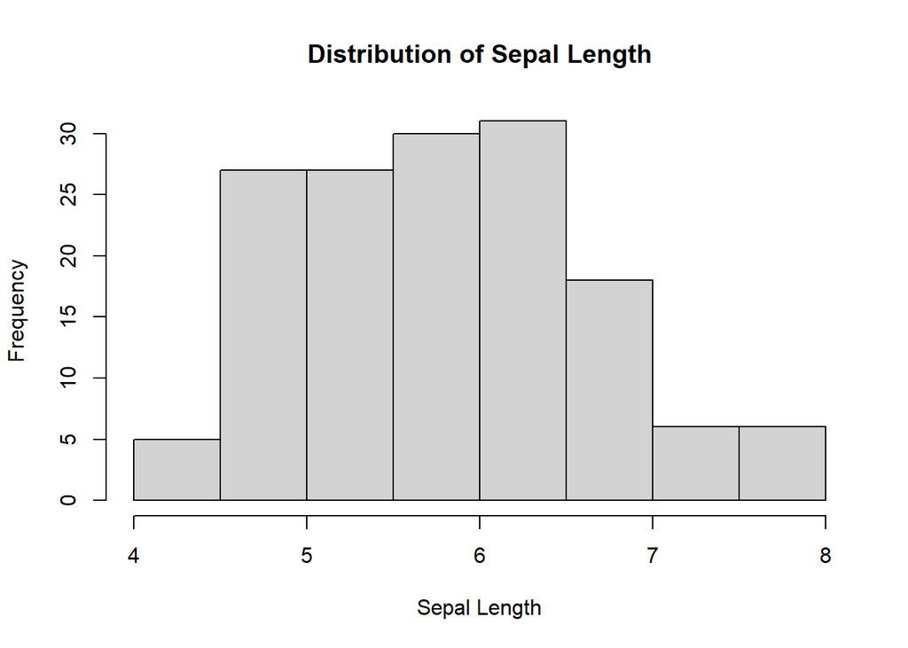

```r
# Histogram for Sepal Length

hist(iris$Sepal.Length, main = "Distribution of Sepal Length", xlab = "Sepal Length")
```

Length of Sepals: The length of the sepals on average is 5.843 cm. The range of the interquartile (IQR) is 5.1 cm (Q1) to 6.4 cm (Q3). Sepal Breadth:

The breadth of the sepals varies from 2.0 to 4.4 cm. Sepal widths average about 3.057 centimeters. The interquartile range (IQR) is 2.8 cm (Q1)–3.3 cm (Q3). Length of Petals:

There is a range of 0.1 to 2.5 cm in petal width. The petal width on average is 1.199 cm. Between 0.3 cm (Q1) and 1.8 cm (Q3) is the IQR range. Distribution of Species:Three species (setosa, versicolor, and virginica) with fifty samples apiece make up the dataset. There are 150 samples altogether in the dataset, 50 of each species, representing them evenly. These observations offer a thorough comprehension of the dataset’s iris species distribution, ranges, and central tendencies of the measurements.

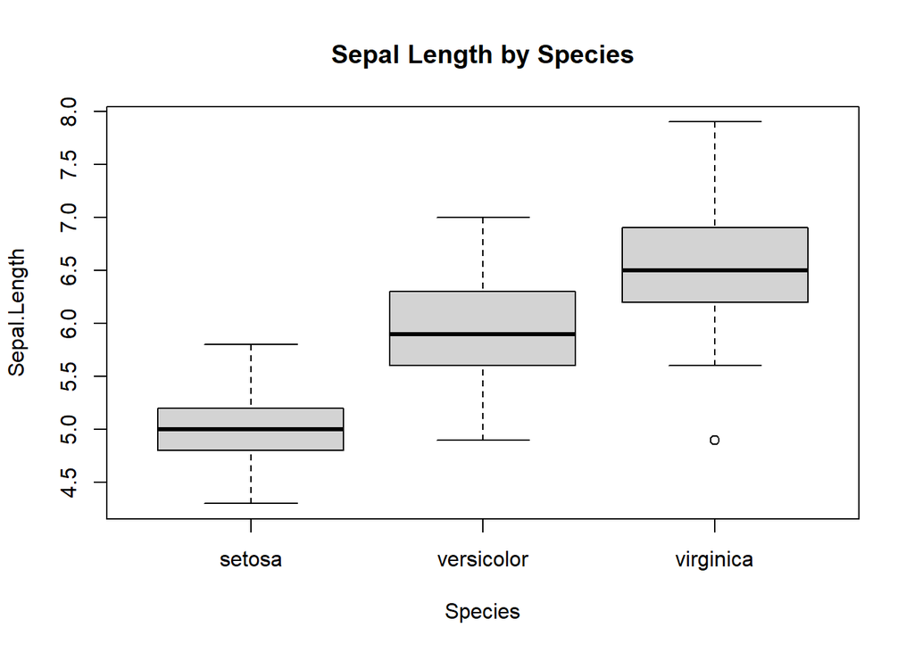

```r
# Similarly, create histograms for other numerical variables like Sepal.Width, Petal.Length, Petal.Width
# Boxplot comparing Species and Sepal Length
boxplot(Sepal.Length ~ Species, data = iris, main = "Sepal Length by Species")
```

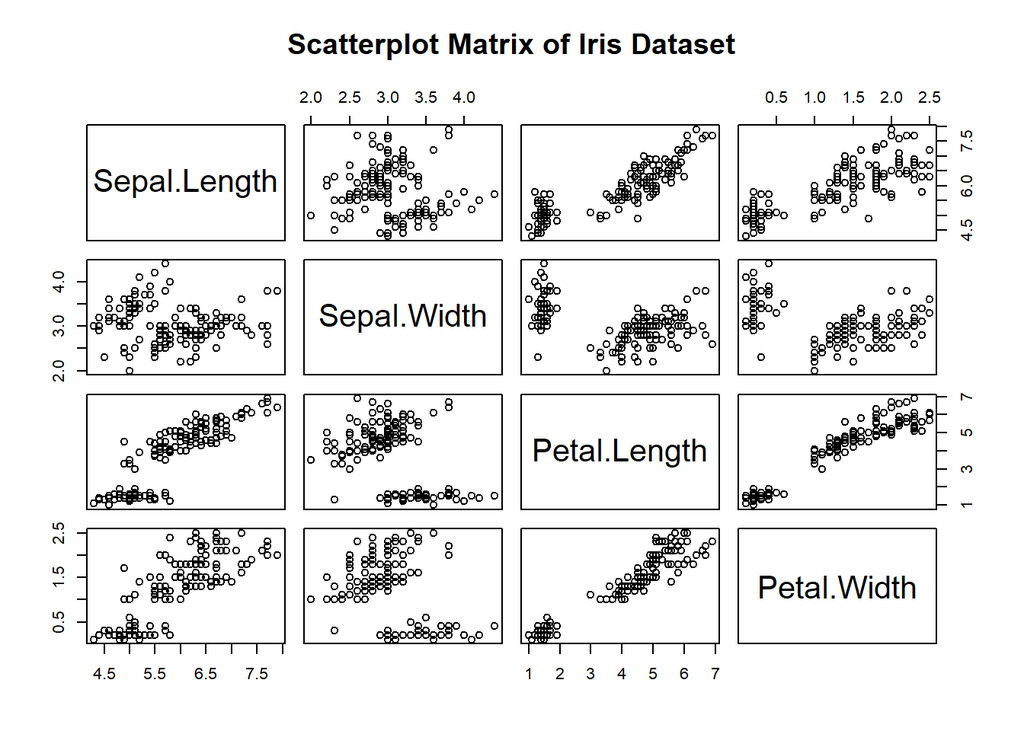

```r
# Scatterplot matrix to visualize relationships between variables
pairs(iris[, 1:4], main = "Scatterplot Matrix of Iris Dataset")
```

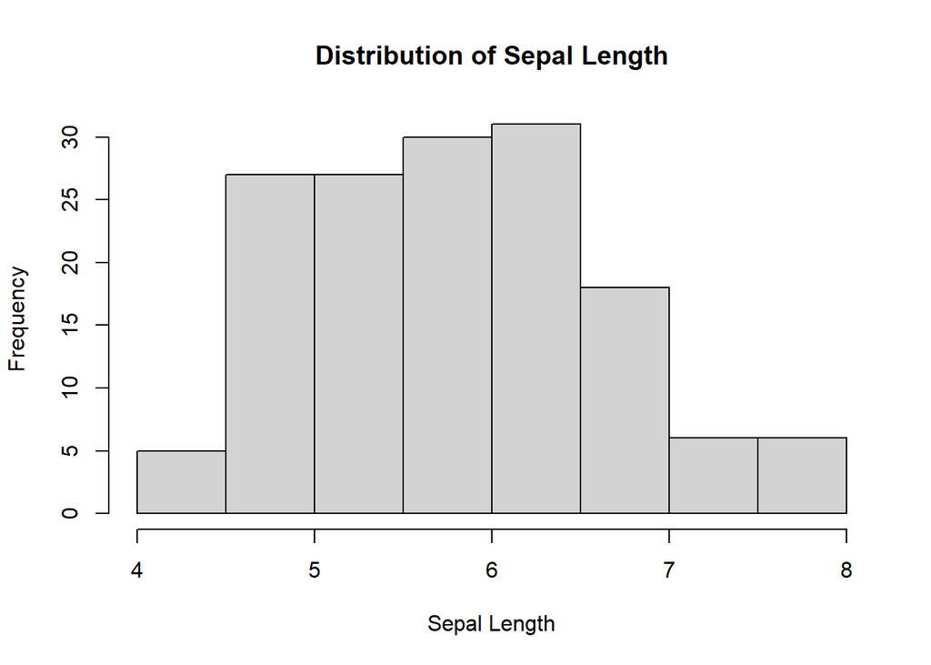

```r
# Histogram for Sepal Length
hist(iris$Sepal.Length, main = "Distribution of Sepal Length", xlab = "Sepal Length")
```

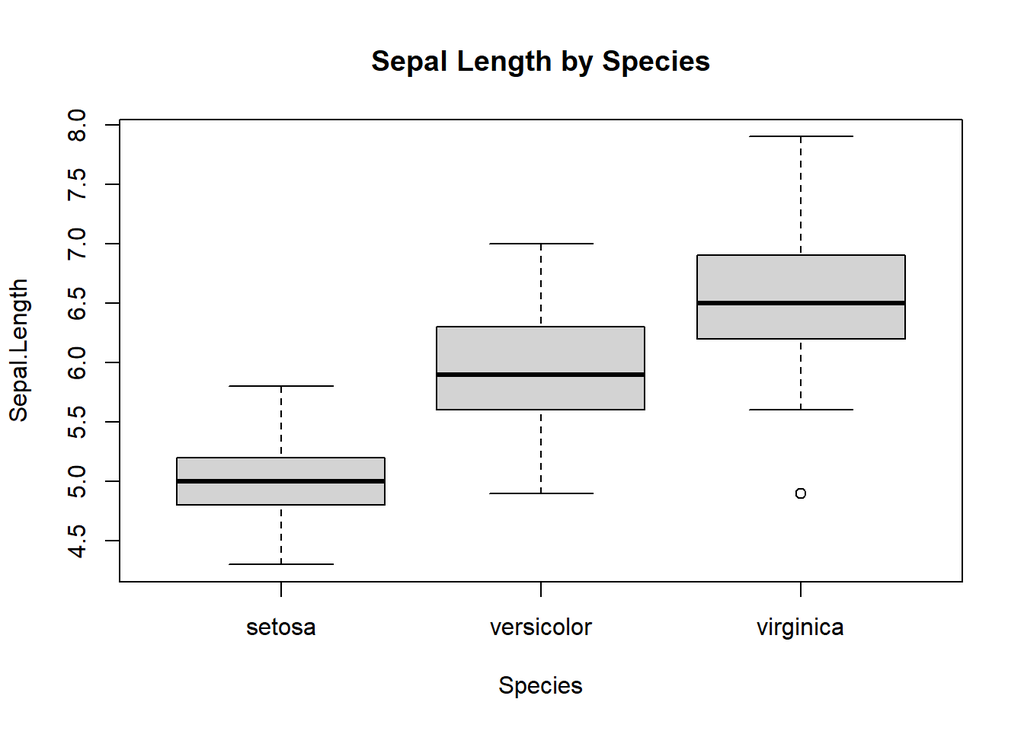

```r
# Similarly, create histograms for other numerical variables like Sepal.Width, Petal.Length, Petal.Width
# Boxplot comparing Species and Sepal Length
boxplot(Sepal.Length ~ Species, data = iris, main = "Sepal Length by Species")
```

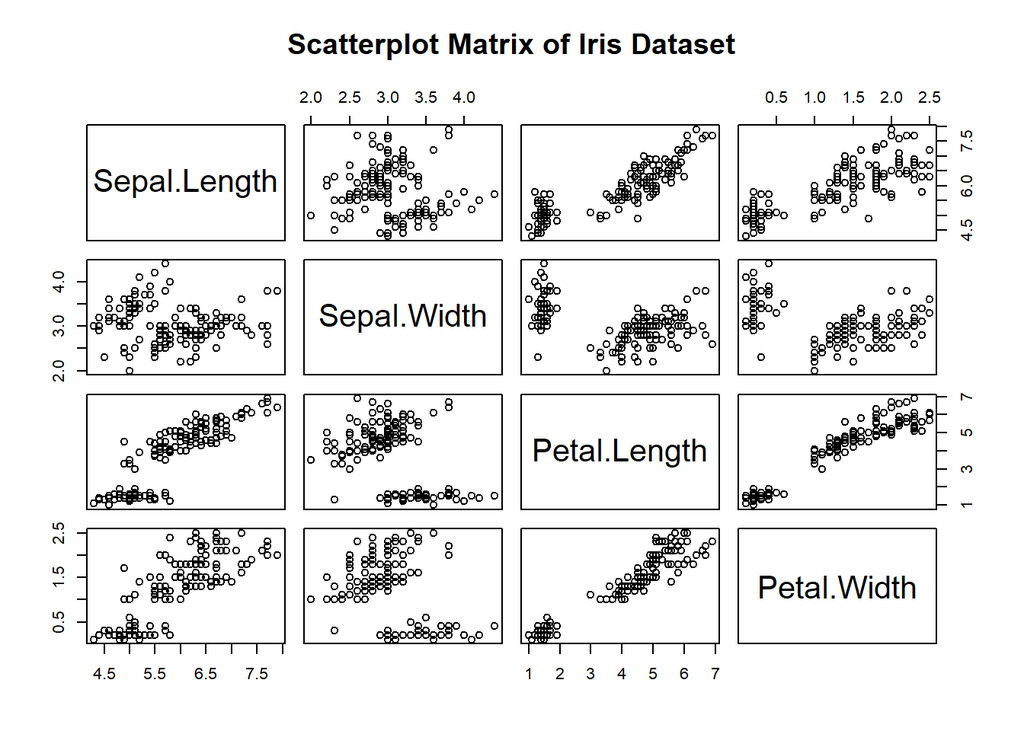

```r
# Scatterplot matrix to visualize relationships between variables
pairs(iris[, 1:4], main = "Scatterplot Matrix of Iris Dataset")
```